# Report

For my experiments, I used the Magic Telescope dataset, which is used to classify whether gamma radiation has been detected, based on advanced measurements. All variables in this dataset are continuous, so no special preprocessing is needed.

|  | fLength: | fWidth: | fSize: | fConc: | fConc1: | fAsym: | fM3Long: | fM3Trans: | fAlpha: | fDist: | TARGET |
| --- | --- | --- | --- | --- | --- | --- | --- | --- | --- | --- | --- |
| 0 | 28.7967 | 16.0021 | 2.6449 | 0.3918 | 0.1982 | 27.7004 | 22.0110 | -8.2027 | 40.0920 | 81.8828 | g |
| 1 | 31.6036 | 11.7235 | 2.5185 | 0.5303 | 0.3773 | 26.2722 | 23.8238 | -9.9574 | 6.3609 | 205.2610 | g |
| 2 | 162.0520 | 136.0310 | 4.0612 | 0.0374 | 0.0187 | 116.7410 | -64.8580 | -45.2160 | 76.9600 | 256.7880 | g |
| 3 | 23.8172 | 9.5728 | 2.3385 | 0.6147 | 0.3922 | 27.2107 | -6.4633 | -7.1513 | 10.4490 | 116.7370 | g |
| 4 | 75.1362 | 30.9205 | 3.1611 | 0.3168 | 0.1832 | -5.5277 | 28.5525 | 21.8393 | 4.6480 | 356.4620 | g |
| ... | ... | ... | ... | ... | ... | ... | ... | ... | ... | ... | ... |
| 19015 | 21.3846 | 10.9170 | 2.6161 | 0.5857 | 0.3934 | 15.2618 | 11.5245 | 2.8766 | 2.4229 | 106.8258 | h |
| 19016 | 28.9452 | 6.7020 | 2.2672 | 0.5351 | 0.2784 | 37.0816 | 13.1853 | -2.9632 | 86.7975 | 247.4560 | h |
| 19017 | 75.4455 | 47.5305 | 3.4483 | 0.1417 | 0.0549 | -9.3561 | 41.0562 | -9.4662 | 30.2987 | 256.5166 | h |
| 19018 | 120.5135 | 76.9018 | 3.9939 | 0.0944 | 0.0683 | 5.8043 | -93.5224 | -63.8389 | 84.6874 | 408.3166 | h |
| 19019 | 187.1814 | 53.0014 | 3.2093 | 0.2876 | 0.1539 | -167.3125 | -168.4558 | 31.4755 | 52.7310 | 272.3174 | h |

19020 rows × 11 columns

On this data, I trained an XGBoost model with 100 estimators and a maximum depth of 3. Before training, I divided the set into training and test sets to then evaluate the model. I obtained an accuracy of 0.8723 and an AUC of 0.9318.

I chose two observations, the first positive and the second negative, to see how the model would behave. Below I show the observations I selected.

|  | fLength: | fWidth: | fSize: | fConc: | fConc1: | fAsym: | fM3Long: | fM3Trans: | fAlpha: | fDist: |
| --- | --- | --- | --- | --- | --- | --- | --- | --- | --- | --- |
| 0 | 28.7967 | 16.0021 | 2.6449 | 0.3918 | 0.1982 | 27.7004 | 22.0110 | -8.2027 | 40.092 | 81.8828 |
| 19019 | 187.1814 | 53.0014 | 3.2093 | 0.2876 | 0.1539 | -167.3125 | -168.4558 | 31.4755 | 52.731 | 272.3174 |

The model classified both cases well, for the first I got a prediction of 0.816 and for the second I got a prediction of 0.0006. To see where these predictions came from, I used the LIME decomposition.

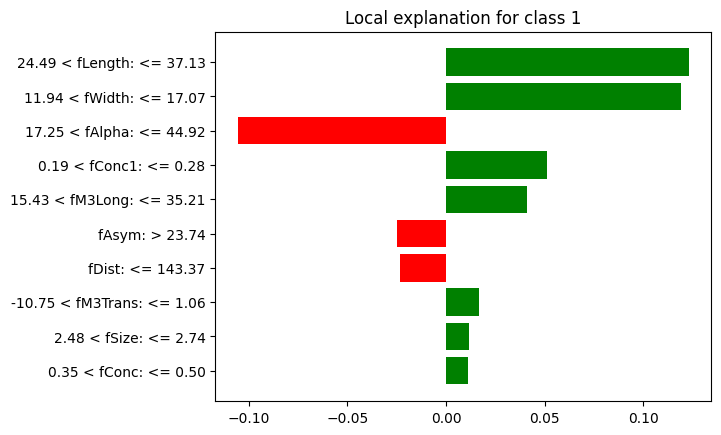

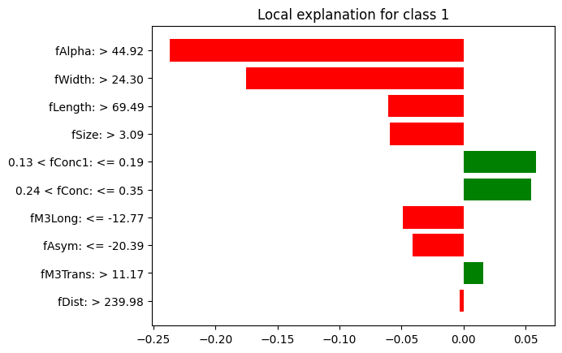

For the first prediction, moderate values of fLength and fWidth were crucial. The negative classification of the second was determined by high values of fAlpha and fWidth.

To better analyse the model, I selected 5 observations that should be classified as gamma radiation and compared the results.

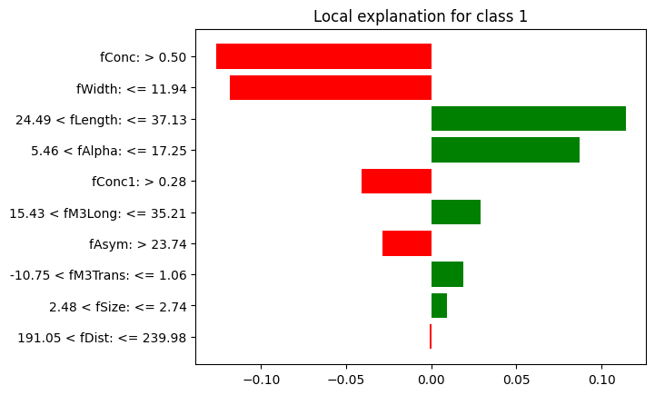

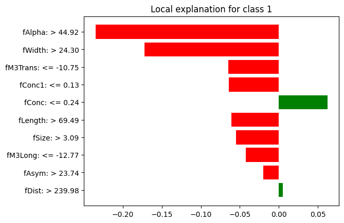

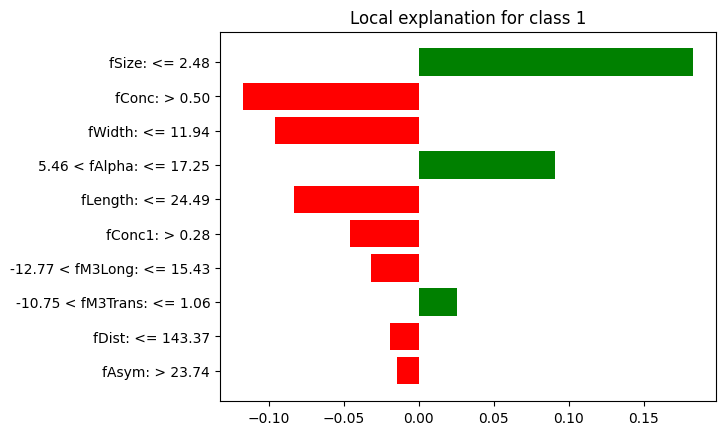

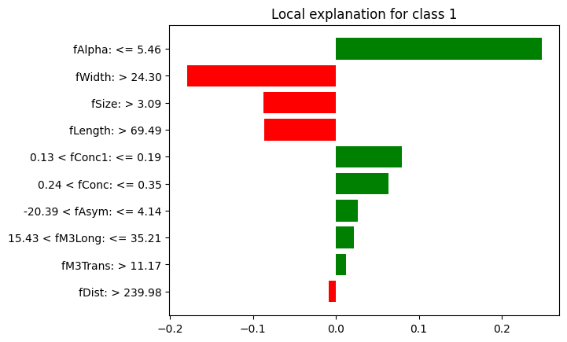

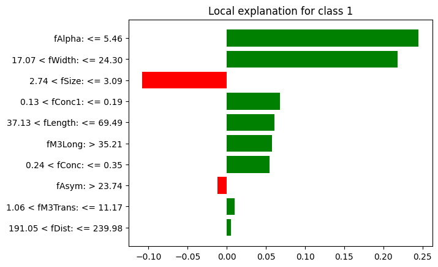

Of these 5 observations, one was classified incorrectly. The model got the second one wrong. Thanks to the LIME decomposition, we can see that this was due to the high values of fAlpha and fWidth. We can also see that 4 of the 5 selected observations have high fAsym values. This factor, however, has a negative impact on the prediction, so in their cases the prediction was lowered.

I also trained a second model, AdaBoost, on the same dataset. I performed its evaluation in an analogous manner and obtained an accuracy of 0.8391 and an AUC of 0.8944. I compared the predictive explanations of the two models for the two observations I mentioned above.

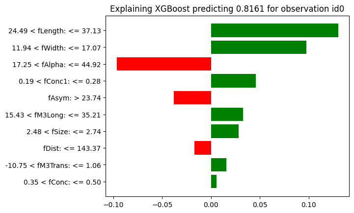

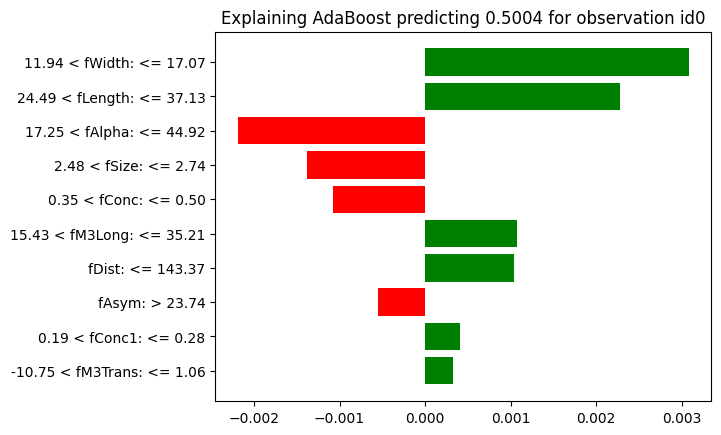

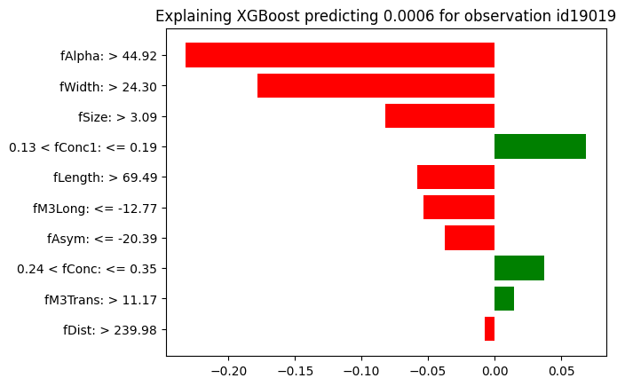

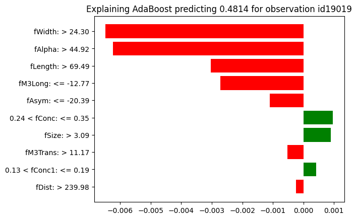

We can see some inaccuracies here. For the first observation, let us pay attention to the feature fDist. In the XGBoost model it had a negative impact on the prediction, while in the AdaBoost model it was already clearly positive. We can observe a similar situation for the second observation and the variable fM3Trans. It had a positive effect in one model and a negative effect in the other.

# Appendix

```python
!pip install dalex
!pip install lime
```

```
     ━━━━━━━━━━━━━━━━━━━━━━━━━━━━━━━━━━━━━━━━ 1.0/1.0 MB 15.9 MB/s eta 0:00:00
  Preparing metadata (setup.py) ... done
     ━━━━━━━━━━━━━━━━━━━━━━━━━━━━━━━━━━━━━━━━ 275.7/275.7 kB 4.1 MB/s eta 0:00:00
  Preparing metadata (setup.py) ... done
```

```python
import dalex as dx
import xgboost
import lime
import sklearn
import pandas as pd
import numpy as np
import matplotlib.pyplot as plt
from sklearn.metrics import roc_auc_score, accuracy_score
from sklearn.model_selection import train_test_split
from sklearn.ensemble import AdaBoostClassifier
```

```python
df = pd.read_csv('MagicTelescope.csv').dropna()

X = df.drop(columns='TARGET').iloc[:,1:]
y = (df.TARGET == "g")

X_train, X_test, y_train, y_test = train_test_split(X, y, test_size=0.25, random_state=17)
```

```python
model = xgboost.XGBClassifier(
    n_estimators=100,
    max_depth=3,
    use_label_encoder=False,
    eval_metric="logloss",
)

model.fit(X_train, y_train)
```

```
XGBClassifier(base_score=None, booster=None, callbacks=None,
              colsample_bylevel=None, colsample_bynode=None,
              colsample_bytree=None, device=None, early_stopping_rounds=None,
              enable_categorical=False, eval_metric='logloss',
              feature_types=None, gamma=None, grow_policy=None,
              importance_type=None, interaction_constraints=None,
              learning_rate=None, max_bin=None, max_cat_threshold=None,
              max_cat_to_onehot=None, max_delta_step=None, max_depth=3,
              max_leaves=None, min_child_weight=None, missing=nan,
              monotone_constraints=None, multi_strategy=None, n_estimators=100,
              n_jobs=None, num_parallel_tree=None, random_state=None, ...)
```

```python
explainer = dx.Explainer(model, X_test, y_test)
explainer.model_performance(cutoff=y.mean())
```

```
Preparation of a new explainer is initiated

  -> data              : 4755 rows 10 cols
  -> target variable   : Parameter 'y' was a pandas.Series. Converted to a numpy.ndarray.
  -> target variable   : 4755 values
  -> model_class       : xgboost.sklearn.XGBClassifier (default)
  -> label             : Not specified, model's class short name will be used. (default)
  -> predict function  : <function yhat_proba_default at 0x7f5604126b90> will be used (default)
  -> predict function  : Accepts pandas.DataFrame and numpy.ndarray.
  -> predicted values  : min = 1.88e-05, mean = 0.655, max = 0.998
  -> model type        : classification will be used (default)
  -> residual function : difference between y and yhat (default)
  -> residuals         : min = -0.99, mean = -0.0143, max = 0.993
  -> model_info        : package xgboost

A new explainer has been created!
```

|  | recall | precision | f1 | accuracy | auc |
| --- | --- | --- | --- | --- | --- |
| XGBClassifier | 0.908733 | 0.893768 | 0.901188 | 0.872345 | 0.931852 |

```python
observation1 = X.iloc[[0]]
print(explainer.predict(observation1))
observation2 = X.iloc[[-1]]
print(explainer.predict(observation2))
```

```
[0.8160999]
[0.00057204]
```

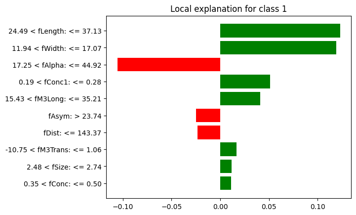

```python
explanation1 = explainer.predict_surrogate(observation1)
explanation1.plot()
```

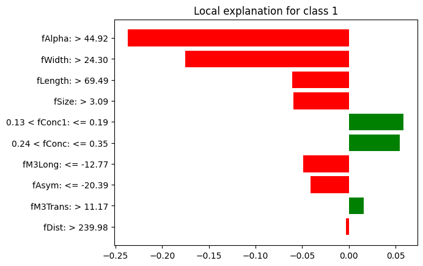

```python
explanation2 = explainer.predict_surrogate(observation2)
explanation2.plot()
```

```python
for i in range(5):
  observation = X.iloc[[i+1]]
  explanation = explainer.predict_surrogate(observation)
  explanation.plot()
```

[output not shown]

```python
ada = AdaBoostClassifier(n_estimators=100, random_state=0)
ada.fit(X_train, y_train)
```

```
AdaBoostClassifier(n_estimators=100, random_state=0)
```

```python
explainer_ada = dx.Explainer(ada, X_test, y_test)
```

```
Preparation of a new explainer is initiated

  -> data              : 4755 rows 10 cols
  -> target variable   : Parameter 'y' was a pandas.Series. Converted to a numpy.ndarray.
  -> target variable   : 4755 values
  -> model_class       : sklearn.ensemble._weight_boosting.AdaBoostClassifier (default)
  -> label             : Not specified, model's class short name will be used. (default)
  -> predict function  : <function yhat_proba_default at 0x7f5604126b90> will be used (default)
  -> predict function  : Accepts pandas.DataFrame and numpy.ndarray.
  -> predicted values  : min = 0.381, mean = 0.502, max = 0.519
  -> model type        : classification will be used (default)
  -> residual function : difference between y and yhat (default)
  -> residuals         : min = -0.515, mean = 0.139, max = 0.596
  -> model_info        : package sklearn

A new explainer has been created!
```

```python
explainer_ada.model_performance()
```

|  | recall | precision | f1 | accuracy | auc |
| --- | --- | --- | --- | --- | --- |
| AdaBoostClassifier | 0.923506 | 0.840957 | 0.8803 | 0.839117 | 0.894419 |

```python
explanation = explainer.predict_surrogate(observation1)
explanation_ada = explainer_ada.predict_surrogate(observation1)

explanation.plot(return_figure=True)
_ = plt.title(f'Explaining XGBoost predicting {np.round(explainer.predict(observation1).item(), 4)} for observation id0')

explanation_ada.plot(return_figure=True)
_ = plt.title(f'Explaining AdaBoost predicting {np.round(explainer_ada.predict(observation1).item(), 4)} for observation id0')
```

[output not shown]

```python
explanation = explainer.predict_surrogate(observation2)
explanation_ada = explainer_ada.predict_surrogate(observation2)

explanation.plot(return_figure=True)
_ = plt.title(f'Explaining XGBoost predicting {np.round(explainer.predict(observation2).item(), 4)} for observation id19019')

explanation_ada.plot(return_figure=True)
_ = plt.title(f'Explaining AdaBoost predicting {np.round(explainer_ada.predict(observation2).item(), 4)} for observation id19019')
```

[output not shown]

## Conversion

```python
%%shell
jupyter nbconvert --to html --template=classic /content/Homework3.ipynb
```